# Introduction

In this challenge, Santander invites Kagglers to help them identify which customers will make a specific transaction in the future, irrespective of the amount of money transacted. The data provided for this competition has the same structure as the real data they have available to solve this problem.

The data is anonimyzed, each row containing 200 numerical values identified just with a number.

Data: https://www.kaggle.com/c/santander-customer-transaction-prediction/overview/evaluation

Reference Link: https://www.youtube.com/watch?v=LEWpRlaEJO8

## Business problem

Based on the data given for every user we have to predict wheater the user will do the transaction in future or not.

## ML problem question

- This one is a classical Binary classification machine learing problem.
- There are 2 classes in the target 0 and 1.
- 0 means not do transaction and 1 means will do transaction.

## Evaluation Metrix

The Evaluation metrix is the AUC and we have to make sure to get AUC as high as possible.

## Mounting the Drive

```python
from google.colab import drive
drive.mount('/content/drive')
```

```
Go to this URL in a browser: https://accounts.google.com/o/oauth2/auth?client_id=947318989803-6bn6qk8qdgf4n4g3pfee6491hc0brc4i.apps.googleusercontent.com&redirect_uri=urn%3aietf%3awg%3aoauth%3a2.0%3aoob&response_type=code&scope=email%20https%3a%2f%2fwww.googleapis.com%2fauth%2fdocs.test%20https%3a%2…

Enter your authorization code:
··········
```

```python
cd drive/My\ Drive/self_case_study_1
```

```
[Errno 2] No such file or directory: 'drive/My Drive/self_case_study_1'
/content/drive/My Drive/self_case_study_1
```

## Loading the data from the kaggle

```python
!wget --header="Host: storage.googleapis.com" --header="User-Agent: Mozilla/5.0 (X11; Linux x86_64) AppleWebKit/537.36 (KHTML, like Gecko) Chrome/78.0.3904.108 Safari/537.36" --header="Accept: text/html,application/xhtml+xml,application/xml;q=0.9,image/webp,image/apng,*/*;q=0.8,application/signed-exchange;v=b3" --header="Accept-Language: en-GB,en-US;q=0.9,en;q=0.8" --header="Referer: https://www.kaggle.com/" "https://storage.googleapis.com/kaggle-competitions-data/kaggle/10385/298493/train.csv.zip?GoogleAccessId=web-data@kaggle-161607.iam.gserviceaccount.com&Expires=1575271319&Signature=MR8AlCGs9Whsd9zMt3Tm%2BEIWiLFt2ehTuwOOgU8qRb6aqSgRs0b3Vs%2FgKFzrLqbB%2BJYQYxB3sG2BWI0lOwFa5x7bvgAwsVbGd32E6W9JT%2B3uRjfuIDgx%2F%2FmON00MT8Uzx0d%2BADCWBPhbm%2FFCpeyrJLMcvMyC5YcHfAs77UN9wolOi3G9tVfs1UQO9KA7gRLXjVtPqqfDJD9fR6Cipcyhv4OCiNJlr%2FN835eyyLgii961FhYSrazlKZvK1xNW7KAZGB8OorFk3a8mdeXvUoGeYpdfzLEgp2jHr7QDrbWdomBbNBrI87kP1o3rwWpkx3%2BHTpxwei6hg2qa7y18z12zPg%3D%3D" -O "train.csv.zip" -c
```

```
--2019-11-29 07:32:38--  https://storage.googleapis.com/kaggle-competitions-data/kaggle/10385/298493/train.csv.zip?GoogleAccessId=web-data@kaggle-161607.iam.gserviceaccount.com&Expires=1575271319&Signature=MR8AlCGs9Whsd9zMt3Tm%2BEIWiLFt2ehTuwOOgU8qRb6aqSgRs0b3Vs%2FgKFzrLqbB%2BJYQYxB3sG2BWI0lOwFa5x7b…
Resolving storage.googleapis.com (storage.googleapis.com)... 173.194.203.128, 2607:f8b0:400e:c07::80
Connecting to storage.googleapis.com (storage.googleapis.com)|173.194.203.128|:443... connected.
HTTP request sent, awaiting response... 200 OK
Length: 128240759 (122M) [application/zip]
Saving to: ‘train.csv.zip’

train.csv.zip       100%[===================>] 122.30M  90.3MB/s    in 1.4s

2019-11-29 07:32:39 (90.3 MB/s) - ‘train.csv.zip’ saved [128240759/128240759]
```

## Extracting the data

```python
!7z e train.csv.zip
```

```
7-Zip [64] 16.02 : Copyright (c) 1999-2016 Igor Pavlov : 2016-05-21
p7zip Version 16.02 (locale=en_US.UTF-8,Utf16=on,HugeFiles=on,64 bits,2 CPUs Intel(R) Xeon(R) CPU @ 2.20GHz (406F0),ASM,AES-NI)

Scanning the drive for archives:
  0M Scan         1 file, 128240759 bytes (123 MiB)

Extracting archive: train.csv.zip
--
Path = train.csv.zip
Type = zip
Physical Size = 128240759

  0%      4% - train.csv                  9% - train.csv                 14% - train.csv                 18% - train.csv                 23% - train.csv                 28% - train.csv                 34% - train.csv                 39% - train.csv                 43% - train.csv                 47%…

Size:       302133017
Compressed: 128240759
```

```python
!7z e test.csv.zip
```

```
7-Zip [64] 16.02 : Copyright (c) 1999-2016 Igor Pavlov : 2016-05-21
p7zip Version 16.02 (locale=en_US.UTF-8,Utf16=on,HugeFiles=on,64 bits,2 CPUs Intel(R) Xeon(R) CPU @ 2.30GHz (306F0),ASM,AES-NI)

Scanning the drive for archives:
  0M Scan         1 file, 127915900 bytes (122 MiB)

Extracting archive: test.csv.zip
--
Path = test.csv.zip
Type = zip
Physical Size = 127915900

  0%      3% - test.csv                 5% - test.csv                 9% - test.csv                12% - test.csv                15% - test.csv                19% - test.csv                21% - test.csv                24% - test.csv                27% - test.csv                31% - test.csv       …

Size:       301526706
Compressed: 127915900
```

## Importing the libraries

```python
import pandas as pd
import seaborn as sns
import matplotlib.pyplot as plt
import numpy as np
from sklearn.model_selection import train_test_split
from sklearn.metrics import roc_curve, auc,roc_auc_score
from sklearn.model_selection import StratifiedKFold
from sklearn.model_selection import RandomizedSearchCV
import lightgbm as lgb
import timeit
import time
```

```python
! pip install imblearn
```

## Reading the data

```python
data = pd.read_csv('train.csv')#train data
data_test = pd.read_csv('test.csv')#test data
```

```python
data.head()
```

|  | ID_code | target | var_0 | var_1 | var_2 | var_3 | var_4 | var_5 | var_6 | var_7 | var_8 | var_9 | var_10 | var_11 | var_12 | var_13 | var_14 | var_15 | var_16 | var_17 | var_18 | var_19 | var_20 | var_21 | var_22 | var_23 | var_24 | var_25 | var_26 | … |
| --- | --- | --- | --- | --- | --- | --- | --- | --- | --- | --- | --- | --- | --- | --- | --- | --- | --- | --- | --- | --- | --- | --- | --- | --- | --- | --- | --- | --- | --- | --- |
| 0 | train_0 | 0 | 8.9255 | -6.7863 | 11.9081 | 5.0930 | 11.4607 | -9.2834 | 5.1187 | 18.6266 | -4.9200 | 5.7470 | 2.9252 | 3.1821 | 14.0137 | 0.5745 | 8.7989 | 14.5691 | 5.7487 | -7.2393 | 4.2840 | 30.7133 | 10.5350 | 16.2191 | 2.5791 | 2.4716 | 14.3831 | 13.4325 | -5.1488 | … |
| 1 | train_1 | 0 | 11.5006 | -4.1473 | 13.8588 | 5.3890 | 12.3622 | 7.0433 | 5.6208 | 16.5338 | 3.1468 | 8.0851 | -0.4032 | 8.0585 | 14.0239 | 8.4135 | 5.4345 | 13.7003 | 13.8275 | -15.5849 | 7.8000 | 28.5708 | 3.4287 | 2.7407 | 8.5524 | 3.3716 | 6.9779 | 13.8910 | -11.7684 | … |
| 2 | train_2 | 0 | 8.6093 | -2.7457 | 12.0805 | 7.8928 | 10.5825 | -9.0837 | 6.9427 | 14.6155 | -4.9193 | 5.9525 | -0.3249 | -11.2648 | 14.1929 | 7.3124 | 7.5244 | 14.6472 | 7.6782 | -1.7395 | 4.7011 | 20.4775 | 17.7559 | 18.1377 | 1.2145 | 3.5137 | 5.6777 | 13.2177 | -7.9940 | … |
| 3 | train_3 | 0 | 11.0604 | -2.1518 | 8.9522 | 7.1957 | 12.5846 | -1.8361 | 5.8428 | 14.9250 | -5.8609 | 8.2450 | 2.3061 | 2.8102 | 13.8463 | 11.9704 | 6.4569 | 14.8372 | 10.7430 | -0.4299 | 15.9426 | 13.7257 | 20.3010 | 12.5579 | 6.8202 | 2.7229 | 12.1354 | 13.7367 | 0.8135 | … |
| 4 | train_4 | 0 | 9.8369 | -1.4834 | 12.8746 | 6.6375 | 12.2772 | 2.4486 | 5.9405 | 19.2514 | 6.2654 | 7.6784 | -9.4458 | -12.1419 | 13.8481 | 7.8895 | 7.7894 | 15.0553 | 8.4871 | -3.0680 | 6.5263 | 11.3152 | 21.4246 | 18.9608 | 10.1102 | 2.7142 | 14.2080 | 13.5433 | 3.1736 | … |

5 rows × 202 columns

```python
data_test.head()
```

|  | ID_code | var_0 | var_1 | var_2 | var_3 | var_4 | var_5 | var_6 | var_7 | var_8 | var_9 | var_10 | var_11 | var_12 | var_13 | var_14 | var_15 | var_16 | var_17 | var_18 | var_19 | var_20 | var_21 | var_22 | var_23 | var_24 | var_25 | var_26 | var_27 | … |
| --- | --- | --- | --- | --- | --- | --- | --- | --- | --- | --- | --- | --- | --- | --- | --- | --- | --- | --- | --- | --- | --- | --- | --- | --- | --- | --- | --- | --- | --- | --- |
| 0 | test_0 | 11.0656 | 7.7798 | 12.9536 | 9.4292 | 11.4327 | -2.3805 | 5.8493 | 18.2675 | 2.1337 | 8.8100 | -2.0248 | -4.3554 | 13.9696 | 0.3458 | 7.5408 | 14.5001 | 7.7028 | -19.0919 | 15.5806 | 16.1763 | 3.7088 | 18.8064 | 1.5899 | 3.0654 | 6.4509 | 14.1192 | -9.4902 | -2.1917 | … |
| 1 | test_1 | 8.5304 | 1.2543 | 11.3047 | 5.1858 | 9.1974 | -4.0117 | 6.0196 | 18.6316 | -4.4131 | 5.9739 | -1.3809 | -0.3310 | 14.1129 | 2.5667 | 5.4988 | 14.1853 | 7.0196 | 4.6564 | 29.1609 | 0.0910 | 12.1469 | 3.1389 | 5.2578 | 2.4228 | 16.2064 | 13.5023 | -5.2341 | -3.6648 | … |
| 2 | test_2 | 5.4827 | -10.3581 | 10.1407 | 7.0479 | 10.2628 | 9.8052 | 4.8950 | 20.2537 | 1.5233 | 8.3442 | -4.7057 | -3.0422 | 13.6751 | 3.8183 | 10.8535 | 14.2126 | 9.8837 | 2.6541 | 21.2181 | 20.8163 | 12.4666 | 12.3696 | 4.7473 | 2.7936 | 5.2189 | 13.5670 | -15.4246 | -0.1655 | … |
| 3 | test_3 | 8.5374 | -1.3222 | 12.0220 | 6.5749 | 8.8458 | 3.1744 | 4.9397 | 20.5660 | 3.3755 | 7.4578 | 0.0095 | -5.0659 | 14.0526 | 13.5010 | 8.7660 | 14.7352 | 10.0383 | -15.3508 | 2.1273 | 21.4797 | 14.5372 | 12.5527 | 2.9707 | 4.2398 | 13.7796 | 14.1408 | 1.0061 | -1.3479 | … |
| 4 | test_4 | 11.7058 | -0.1327 | 14.1295 | 7.7506 | 9.1035 | -8.5848 | 6.8595 | 10.6048 | 2.9890 | 7.1437 | 5.1025 | -3.2827 | 14.1013 | 8.9672 | 4.7276 | 14.5811 | 11.8615 | 3.1480 | 18.0126 | 13.8006 | 1.6026 | 16.3059 | 6.7954 | 3.6015 | 13.6569 | 13.8807 | 8.6228 | -2.2654 | … |

5 rows × 201 columns

```python
data_1 = data.pop('target')
data['target'] = data_1
```

```python
data.head()
```

|  | ID_code | var_0 | var_1 | var_2 | var_3 | var_4 | var_5 | var_6 | var_7 | var_8 | var_9 | var_10 | var_11 | var_12 | var_13 | var_14 | var_15 | var_16 | var_17 | var_18 | var_19 | var_20 | var_21 | var_22 | var_23 | var_24 | var_25 | var_26 | var_27 | … |
| --- | --- | --- | --- | --- | --- | --- | --- | --- | --- | --- | --- | --- | --- | --- | --- | --- | --- | --- | --- | --- | --- | --- | --- | --- | --- | --- | --- | --- | --- | --- |
| 0 | train_0 | 8.9255 | -6.7863 | 11.9081 | 5.0930 | 11.4607 | -9.2834 | 5.1187 | 18.6266 | -4.9200 | 5.7470 | 2.9252 | 3.1821 | 14.0137 | 0.5745 | 8.7989 | 14.5691 | 5.7487 | -7.2393 | 4.2840 | 30.7133 | 10.5350 | 16.2191 | 2.5791 | 2.4716 | 14.3831 | 13.4325 | -5.1488 | -0.4073 | … |
| 1 | train_1 | 11.5006 | -4.1473 | 13.8588 | 5.3890 | 12.3622 | 7.0433 | 5.6208 | 16.5338 | 3.1468 | 8.0851 | -0.4032 | 8.0585 | 14.0239 | 8.4135 | 5.4345 | 13.7003 | 13.8275 | -15.5849 | 7.8000 | 28.5708 | 3.4287 | 2.7407 | 8.5524 | 3.3716 | 6.9779 | 13.8910 | -11.7684 | -2.5586 | … |
| 2 | train_2 | 8.6093 | -2.7457 | 12.0805 | 7.8928 | 10.5825 | -9.0837 | 6.9427 | 14.6155 | -4.9193 | 5.9525 | -0.3249 | -11.2648 | 14.1929 | 7.3124 | 7.5244 | 14.6472 | 7.6782 | -1.7395 | 4.7011 | 20.4775 | 17.7559 | 18.1377 | 1.2145 | 3.5137 | 5.6777 | 13.2177 | -7.9940 | -2.9029 | … |
| 3 | train_3 | 11.0604 | -2.1518 | 8.9522 | 7.1957 | 12.5846 | -1.8361 | 5.8428 | 14.9250 | -5.8609 | 8.2450 | 2.3061 | 2.8102 | 13.8463 | 11.9704 | 6.4569 | 14.8372 | 10.7430 | -0.4299 | 15.9426 | 13.7257 | 20.3010 | 12.5579 | 6.8202 | 2.7229 | 12.1354 | 13.7367 | 0.8135 | -0.9059 | … |
| 4 | train_4 | 9.8369 | -1.4834 | 12.8746 | 6.6375 | 12.2772 | 2.4486 | 5.9405 | 19.2514 | 6.2654 | 7.6784 | -9.4458 | -12.1419 | 13.8481 | 7.8895 | 7.7894 | 15.0553 | 8.4871 | -3.0680 | 6.5263 | 11.3152 | 21.4246 | 18.9608 | 10.1102 | 2.7142 | 14.2080 | 13.5433 | 3.1736 | -3.3423 | … |

5 rows × 202 columns

```python
data.describe()
```

|  | var_0 | var_1 | var_2 | var_3 | var_4 | var_5 | var_6 | var_7 | var_8 | var_9 | var_10 | var_11 | var_12 | var_13 | var_14 | var_15 | var_16 | var_17 | var_18 | var_19 | var_20 | var_21 | var_22 | var_23 | var_24 | var_25 | var_26 | var_27 | var_28 | … |
| --- | --- | --- | --- | --- | --- | --- | --- | --- | --- | --- | --- | --- | --- | --- | --- | --- | --- | --- | --- | --- | --- | --- | --- | --- | --- | --- | --- | --- | --- | --- |
| count | 200000.000000 | 200000.000000 | 200000.000000 | 200000.000000 | 200000.000000 | 200000.000000 | 200000.000000 | 200000.000000 | 200000.000000 | 200000.000000 | 200000.000000 | 200000.000000 | 200000.000000 | 200000.000000 | 200000.000000 | 200000.000000 | 200000.000000 | 200000.000000 | 200000.000000 | 200000.000000 | 200000.000000 | 200000.000000 | 200000.000000 | 200000.000000 | 200000.000000 | 200000.000000 | 200000.000000 | 200000.000000 | 200000.000000 | … |
| mean | 10.679914 | -1.627622 | 10.715192 | 6.796529 | 11.078333 | -5.065317 | 5.408949 | 16.545850 | 0.284162 | 7.567236 | 0.394340 | -3.245596 | 14.023978 | 8.530232 | 7.537606 | 14.573126 | 9.333264 | -5.696731 | 15.244013 | 12.438567 | 13.290894 | 17.257883 | 4.305430 | 3.019540 | 10.584400 | 13.667496 | -4.055133 | -1.137908 | 5.532980 | … |
| std | 3.040051 | 4.050044 | 2.640894 | 2.043319 | 1.623150 | 7.863267 | 0.866607 | 3.418076 | 3.332634 | 1.235070 | 5.500793 | 5.970253 | 0.190059 | 4.639536 | 2.247908 | 0.411711 | 2.557421 | 6.712612 | 7.851370 | 7.996694 | 5.876254 | 8.196564 | 2.847958 | 0.526893 | 3.777245 | 0.285535 | 5.922210 | 1.523714 | 0.783367 | … |
| min | 0.408400 | -15.043400 | 2.117100 | -0.040200 | 5.074800 | -32.562600 | 2.347300 | 5.349700 | -10.505500 | 3.970500 | -20.731300 | -26.095000 | 13.434600 | -6.011100 | 1.013300 | 13.076900 | 0.635100 | -33.380200 | -10.664200 | -12.402500 | -5.432200 | -10.089000 | -5.322500 | 1.209800 | -0.678400 | 12.720000 | -24.243100 | -6.166800 | 2.089600 | … |
| 25% | 8.453850 | -4.740025 | 8.722475 | 5.254075 | 9.883175 | -11.200350 | 4.767700 | 13.943800 | -2.317800 | 6.618800 | -3.594950 | -7.510600 | 13.894000 | 5.072800 | 5.781875 | 14.262800 | 7.452275 | -10.476225 | 9.177950 | 6.276475 | 8.627800 | 11.551000 | 2.182400 | 2.634100 | 7.613000 | 13.456400 | -8.321725 | -2.307900 | 4.992100 | … |
| 50% | 10.524750 | -1.608050 | 10.580000 | 6.825000 | 11.108250 | -4.833150 | 5.385100 | 16.456800 | 0.393700 | 7.629600 | 0.487300 | -3.286950 | 14.025500 | 8.604250 | 7.520300 | 14.574100 | 9.232050 | -5.666350 | 15.196250 | 12.453900 | 13.196800 | 17.234250 | 4.275150 | 3.008650 | 10.380350 | 13.662500 | -4.196900 | -1.132100 | 5.534850 | … |
| 75% | 12.758200 | 1.358625 | 12.516700 | 8.324100 | 12.261125 | 0.924800 | 6.003000 | 19.102900 | 2.937900 | 8.584425 | 4.382925 | 0.852825 | 14.164200 | 12.274775 | 9.270425 | 14.874500 | 11.055900 | -0.810775 | 21.013325 | 18.433300 | 17.879400 | 23.089050 | 6.293200 | 3.403800 | 13.479600 | 13.863700 | -0.090200 | 0.015625 | 6.093700 | … |
| max | 20.315000 | 10.376800 | 19.353000 | 13.188300 | 16.671400 | 17.251600 | 8.447700 | 27.691800 | 10.151300 | 11.150600 | 18.670200 | 17.188700 | 14.654500 | 22.331500 | 14.937700 | 15.863300 | 17.950600 | 19.025900 | 41.748000 | 35.183000 | 31.285900 | 49.044300 | 14.594500 | 4.875200 | 25.446000 | 14.654600 | 15.675100 | 3.243100 | 8.787400 | … |

8 rows × 201 columns

## Exploratory data analysis

```python
# data.to_csv('data_train.csv', index= False)
data_train = pd.read_csv('data_train.csv')
```

value count for both the target values

```python
data_train['target'].value_counts()
```

```
0    179902
1     20098
Name: target, dtype: int64
```

#### Check for the null value count

```python
data_train.isnull().sum()
```

```
ID_code    0
var_0      0
var_1      0
var_2      0
var_3      0
          ..
var_196    0
var_197    0
var_198    0
var_199    0
target     0
Length: 202, dtype: int64
```

We are checking the data point distribution for both the target values 0 or 1

```
percentage of data belongs to 0 : 89.951 %
percentage of data belongs to 1 : 10.049 %
```

```
[]
```

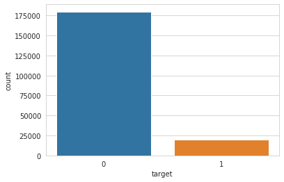

```python
# First check for the distributio of 0 and 1
ax = sns.countplot('target',data=data_train)
print("percentage of data belongs to 0 :", data_train['target'].value_counts()[0]*100/200000,"%")
print("percentage of data belongs to 1 :", data_train['target'].value_counts()[1]*100/200000,"%")
ax.plot()
```

### Observation

- The data is highly imbalanced by looking at the plot
- Around 90% of data belongs to the target class 0 and only 10% of data belongs target class 1

### Checking th distriution of all the feature towards the target value

- Since we have 200 features and they all were anomyzed we have to check all the feature distribution towards the target value.
- For this we creat a function that gives us the distribution of each and every feature towards the target values.

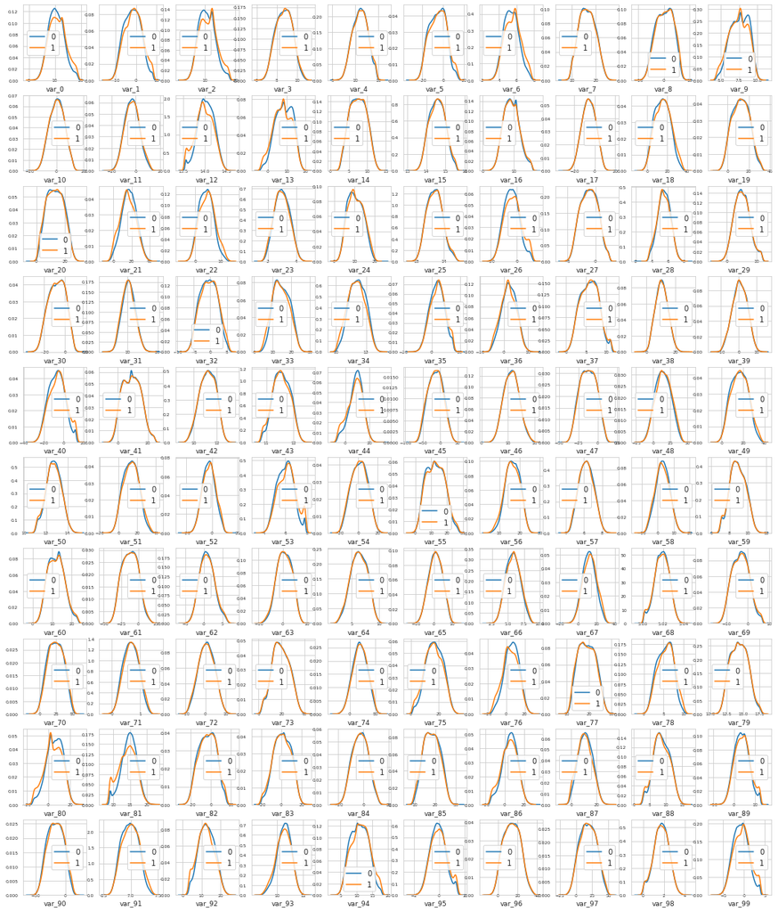

```python
def feature_distribution(data_1,data_2,target_0,target_1,features_list):
    # Here we are setting the style of the plot and grid in it
    sns.set_style('whitegrid')
    plt.figure() # Here we are initializing the plt figure object
    # Here we are creating the subplot and initialzing it size and row col size
    fig, ax = plt.subplots(10,10,figsize=(18,22))
    for  plot_count, feature in enumerate(features_list):
        #plotting the plots here for every plot feature
        plt.subplot(10,10,plot_count+1)
        #plotting the pdf plot for every feature towards the target value
        sns.distplot(data_1[feature], hist=False,label=target_0)
        sns.distplot(data_2[feature], hist=False,label=target_1)
        plt.xlabel(feature, fontsize=9)# Here we are setting the x axis label
        locs, labels = plt.xticks()
        # Here we are setting the ticks for x and y axis
        plt.tick_params(axis='x', which='major', labelsize=6, pad=-6)
        plt.tick_params(axis='y', which='major', labelsize=6)
    plt.show();

## Dstribution for the first 100 features
target_0_data = data.loc[data_train['target'] == 0]
target_1_data = data.loc[data_train['target'] == 1]
features = data.columns.values[1:101]
feature_distribution(target_0_data, target_1_data, '0', '1', features)
```

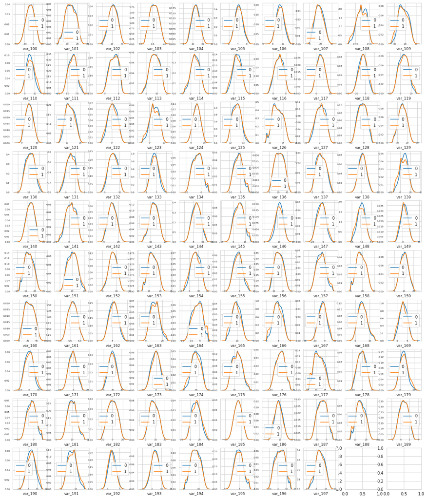

```python
## Dstribution for the rest 100 features
features = data_train.columns.values[101:199]
feature_distribution(target_0_data, target_1_data, '0', '1', features)
```

### Lets check the distribution of mean and std of the data

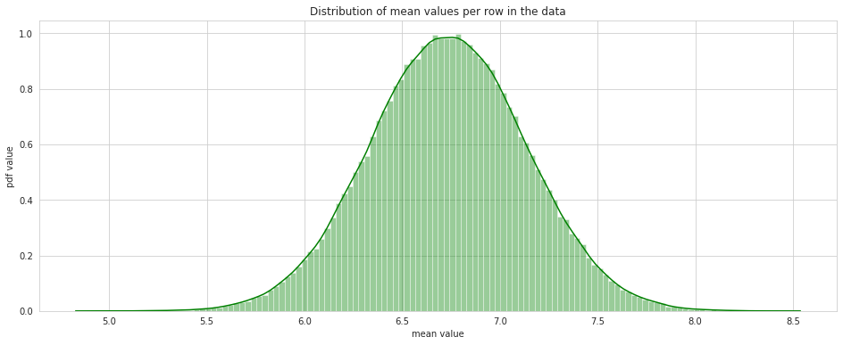

```python
plt.figure(figsize=(16,6))
sns.set_style('whitegrid')
features = data_train.columns.values[1:202]
plt.title("Distribution of mean values per row in the data")
plt.xlabel('mean value')
plt.ylabel('pdf value')
sns.distplot(data_train[features].mean(axis=1),color="green", kde=True,bins=120)
plt.show()
```

### Observation

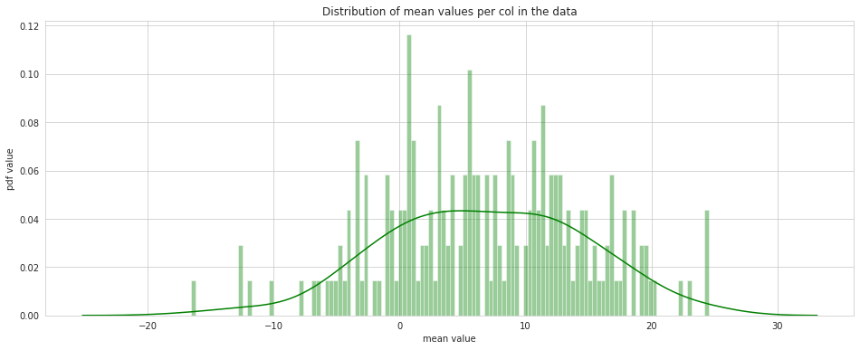

```python
plt.figure(figsize=(16,6))
sns.set_style('whitegrid')
features = data_train.columns.values[1:202]
plt.title("Distribution of mean values per col in the data")
plt.xlabel('mean value')
plt.ylabel('pdf value')
sns.distplot(data_train[features].mean(axis=0),color="green", kde=True,bins=120)
plt.show()
```

### Observation

- The above graph is of the mean distriution of each feature columnwise.
- The columns wise mean distribution is not gaussian
- The mejority of columns having the mean value between -10 and 20

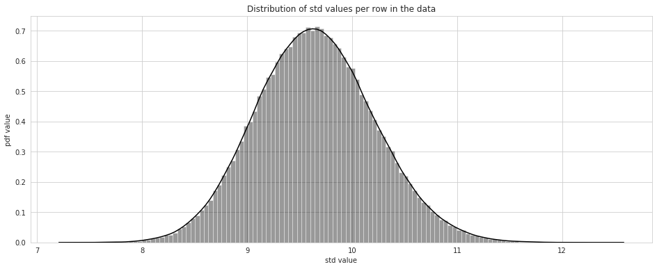

```python
plt.figure(figsize=(16,6))
features = data_train.columns.values[1:202]
plt.title("Distribution of std values per row in the data")
plt.xlabel('std value')
plt.ylabel('pdf value')
sns.distplot(data_train[features].std(axis=1),color="black", kde=True,bins=120)
plt.show()
```

### Observation

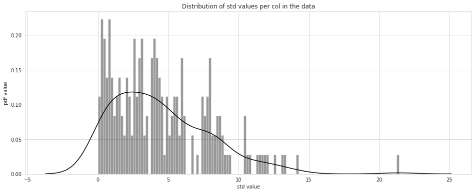

```python
plt.figure(figsize=(16,6))
features = data_train.columns.values[1:202]
plt.title("Distribution of std values per col in the data")
plt.xlabel('std value')
plt.ylabel('pdf value')
sns.distplot(data_train[features].std(axis=0),color="black", kde=True,bins=120)
plt.show()
```

### Observation

- As the graph we can say the distribution of the standard deviation along of features along the column is came from some other distribution.
- There are large number of feature having the deviation in the range of 0 and 6
- with minimum standard deviation of 0 and maximum of around 21 or something.

### Distribution of the mean value dataset, grouped by value of target.

```python
target_0_data = data_train.loc[data_train['target'] == 0]
target_1_data = data_train.loc[data_train['target'] == 1]
```

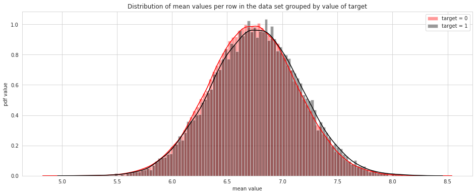

```python
plt.figure(figsize=(16,6))
plt.title("Distribution of mean values per row in the data set grouped by value of target")
plt.xlabel('mean value')
plt.ylabel('pdf value')
sns.distplot(target_0_data[features].mean(axis=1),color="red", kde=True,bins=120, label='target = 0')
sns.distplot(target_1_data[features].mean(axis=1),color="black", kde=True,bins=120, label='target = 1')
plt.legend(); plt.show()
```

### Observation

- The above graph show the mean distribution of every features towards the target
- The distribution of every feature towards each class lookes kind of similar.
- Hence the features will do welll on identifying the target class.

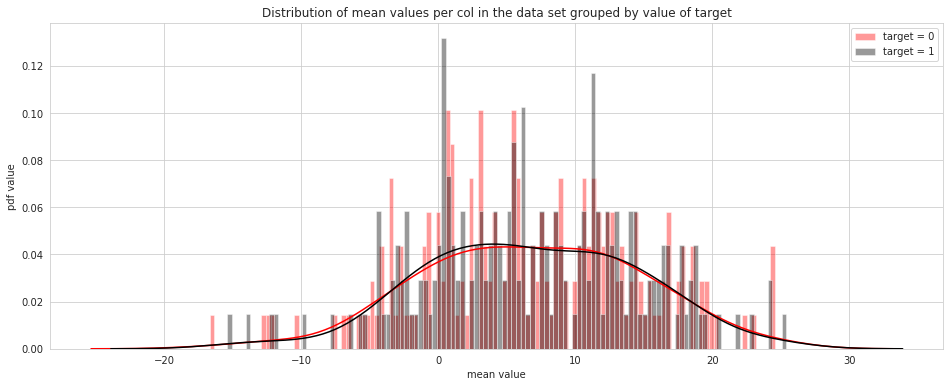

```python
plt.figure(figsize=(16,6))
plt.title("Distribution of mean values per col in the data set grouped by value of target")
plt.xlabel('mean value')
plt.ylabel('pdf value')
sns.distplot(target_0_data[features].mean(axis=0),color="red", kde=True,bins=120, label='target = 0')
sns.distplot(target_1_data[features].mean(axis=0),color="black", kde=True,bins=120, label='target = 1')
plt.legend(); plt.show()
```

#### Observation

- Looking the above graph shows both the distirbution quite similary
- All feature will do we in identifying the target class
- The mejority of features means lies in the range of -10 to 20

## Distribution of min and max value in data as row and col both wise

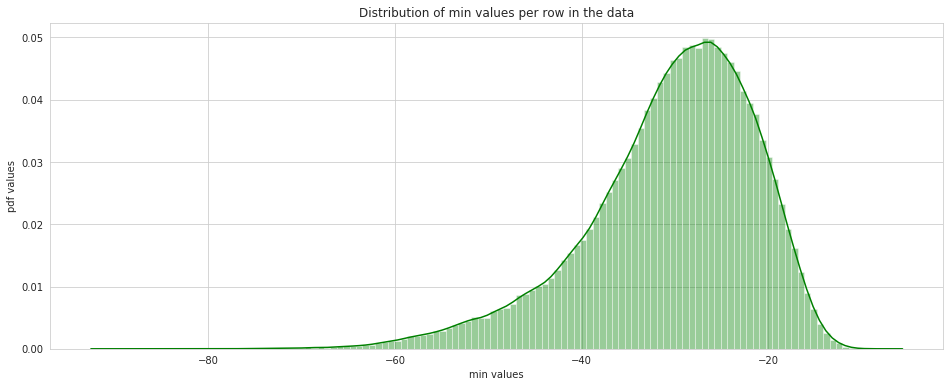

```python
plt.figure(figsize=(16,6))
features = data_train.columns.values[1:202]
plt.title("Distribution of min values per row in the data")
plt.xlabel('min values')
plt.ylabel('pdf values')
sns.distplot(data_train[features].min(axis=1),color="green", kde=True,bins=120)
plt.show()
```

### Observation

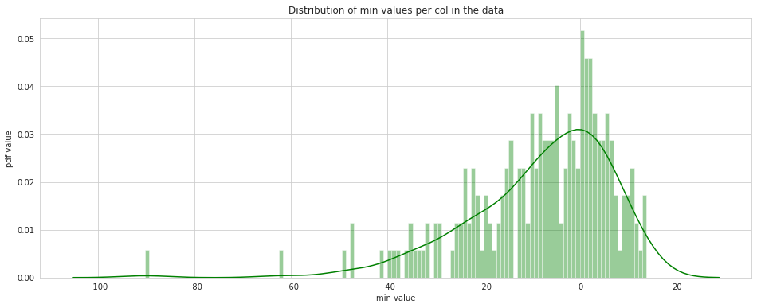

```python
plt.figure(figsize=(16,6))
features = data_train.columns.values[1:202]
plt.title("Distribution of min values per col in the data")
plt.xlabel('min value')
plt.ylabel('pdf value')
sns.distplot(data_train[features].min(axis=0),color="green", kde=True,bins=120)
plt.show()
```

### Observation

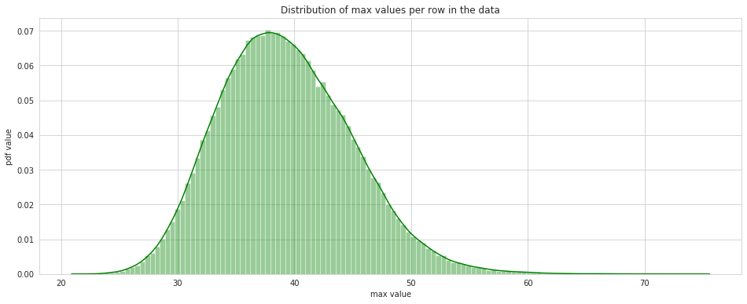

```python
plt.figure(figsize=(16,6))
features = data_train.columns.values[1:202]
plt.title("Distribution of max values per row in the data")
plt.xlabel('max value')
plt.ylabel('pdf value')
sns.distplot(data_train[features].max(axis=1),color="green", kde=True,bins=120)
plt.show()
```

### Observation

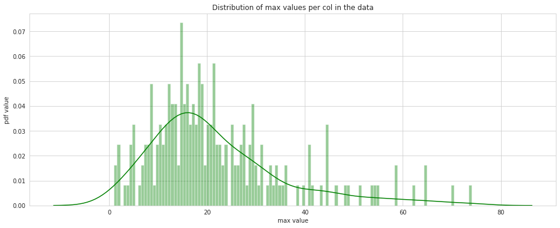

```python
plt.figure(figsize=(16,6))
features = data_train.columns.values[1:202]
plt.title("Distribution of max values per col in the data")
plt.xlabel('max value')
plt.ylabel('pdf value')
sns.distplot(data_train[features].max(axis=0),color="green", kde=True,bins=120)
plt.show()
```

### Observation

- The above distribution is the col wise distribution of the each feature max value.
- we can observe the max value of 80 as the longer tail of the graph is on the right side.

### Now let's check the correation between the features

```python
features = data_train.columns.values[1:200] # Here we are getting all th features
# And here we are calculating the correlation of every featre ad sorting it in ascending order
cor_data = data_train[features].corr().abs().unstack().sort_values(kind="quicksort").reset_index()
cor_data = cor_data[cor_data['level_0'] != cor_data['level_1']]
# cor_data.head(10)
```

#### some most correlated data

```python
cor_data.tail(10)
```

|  | level_0 | level_1 | 0 |
| --- | --- | --- | --- |
| 39392 | var_183 | var_189 | 0.009359 |
| 39393 | var_189 | var_183 | 0.009359 |
| 39394 | var_81 | var_174 | 0.009490 |
| 39395 | var_174 | var_81 | 0.009490 |
| 39396 | var_165 | var_81 | 0.009714 |
| 39397 | var_81 | var_165 | 0.009714 |
| 39398 | var_148 | var_53 | 0.009788 |
| 39399 | var_53 | var_148 | 0.009788 |
| 39400 | var_139 | var_26 | 0.009844 |
| 39401 | var_26 | var_139 | 0.009844 |

#### some least correlated data

```python
cor_data.head(10)
```

|  | level_0 | level_1 | 0 |
| --- | --- | --- | --- |
| 0 | var_75 | var_191 | 2.703975e-08 |
| 1 | var_191 | var_75 | 2.703975e-08 |
| 2 | var_173 | var_6 | 5.942735e-08 |
| 3 | var_6 | var_173 | 5.942735e-08 |
| 4 | var_109 | var_126 | 1.313947e-07 |
| 5 | var_126 | var_109 | 1.313947e-07 |
| 6 | var_144 | var_27 | 1.772502e-07 |
| 7 | var_27 | var_144 | 1.772502e-07 |
| 8 | var_100 | var_177 | 3.116544e-07 |
| 9 | var_177 | var_100 | 3.116544e-07 |

## Training a Baseline model

```python
data_train.head(5)
```

|  | ID_code | var_0 | var_1 | var_2 | var_3 | var_4 | var_5 | var_6 | var_7 | var_8 | var_9 | var_10 | var_11 | var_12 | var_13 | var_14 | var_15 | var_16 | var_17 | var_18 | var_19 | var_20 | var_21 | var_22 | var_23 | var_24 | var_25 | var_26 | var_27 | … |
| --- | --- | --- | --- | --- | --- | --- | --- | --- | --- | --- | --- | --- | --- | --- | --- | --- | --- | --- | --- | --- | --- | --- | --- | --- | --- | --- | --- | --- | --- | --- |
| 0 | train_0 | 8.9255 | -6.7863 | 11.9081 | 5.0930 | 11.4607 | -9.2834 | 5.1187 | 18.6266 | -4.9200 | 5.7470 | 2.9252 | 3.1821 | 14.0137 | 0.5745 | 8.7989 | 14.5691 | 5.7487 | -7.2393 | 4.2840 | 30.7133 | 10.5350 | 16.2191 | 2.5791 | 2.4716 | 14.3831 | 13.4325 | -5.1488 | -0.4073 | … |
| 1 | train_1 | 11.5006 | -4.1473 | 13.8588 | 5.3890 | 12.3622 | 7.0433 | 5.6208 | 16.5338 | 3.1468 | 8.0851 | -0.4032 | 8.0585 | 14.0239 | 8.4135 | 5.4345 | 13.7003 | 13.8275 | -15.5849 | 7.8000 | 28.5708 | 3.4287 | 2.7407 | 8.5524 | 3.3716 | 6.9779 | 13.8910 | -11.7684 | -2.5586 | … |
| 2 | train_2 | 8.6093 | -2.7457 | 12.0805 | 7.8928 | 10.5825 | -9.0837 | 6.9427 | 14.6155 | -4.9193 | 5.9525 | -0.3249 | -11.2648 | 14.1929 | 7.3124 | 7.5244 | 14.6472 | 7.6782 | -1.7395 | 4.7011 | 20.4775 | 17.7559 | 18.1377 | 1.2145 | 3.5137 | 5.6777 | 13.2177 | -7.9940 | -2.9029 | … |
| 3 | train_3 | 11.0604 | -2.1518 | 8.9522 | 7.1957 | 12.5846 | -1.8361 | 5.8428 | 14.9250 | -5.8609 | 8.2450 | 2.3061 | 2.8102 | 13.8463 | 11.9704 | 6.4569 | 14.8372 | 10.7430 | -0.4299 | 15.9426 | 13.7257 | 20.3010 | 12.5579 | 6.8202 | 2.7229 | 12.1354 | 13.7367 | 0.8135 | -0.9059 | … |
| 4 | train_4 | 9.8369 | -1.4834 | 12.8746 | 6.6375 | 12.2772 | 2.4486 | 5.9405 | 19.2514 | 6.2654 | 7.6784 | -9.4458 | -12.1419 | 13.8481 | 7.8895 | 7.7894 | 15.0553 | 8.4871 | -3.0680 | 6.5263 | 11.3152 | 21.4246 | 18.9608 | 10.1102 | 2.7142 | 14.2080 | 13.5433 | 3.1736 | -3.3423 | … |

5 rows × 202 columns

```python
# creating the training and target data
y = data_train['target']
x = data_train.drop(['ID_code','target'],axis=1)
```

```python
# Splitting it into train and cv
X_train, X_cv, y_train, y_cv = train_test_split(x,y ,test_size=0.33,random_state=42)
```

```python
print('Number of data points in train data:', X_train.shape[0])
print('Number of data points in test data:', X_cv.shape[0])
```

```
Number of data points in train data: 134000
Number of data points in test data: 66000
```

```python
def batch_predict(clf, data):
    y_data_pred = []
    tr_loop = data.shape[0] - data.shape[0]%1000
    # consider you X_tr shape is 49041, then your tr_loop will be 49041 - 49041%1000 = 49000
    # in this for loop we will iterate unti the last 1000 multiplier
    for i in range(0, tr_loop, 1000):
        y_data_pred.extend(clf.predict_proba(data[i:i+1000])[:,1])
    # we will be predicting for the last data points
    if data.shape[0]%1000 !=0:
        y_data_pred.extend(clf.predict_proba(data[tr_loop:])[:,1])

    return y_data_pred
```

### Hyperparameter tunning

```python
parameters = {'num_leaves':[6,8,12,16],'learning_rate':[0.01,0.03,0.05,0.1,0.15,0.2],
          'n_estimators':[100,200,500,1000,2000],'max_depth':[3,5,10]} # setting the parameter to be tune
lgb_clf = lgb.LGBMClassifier()# Initializing the Lightgbm model
# tunning the parameter using the randomsearch
lgb_clf_rs = RandomizedSearchCV(lgb_clf, parameters, verbose=10, n_jobs=-1)
lgb_clf_rs.fit(X_train,y_train)# Training the model
print(lgb_clf_rs.best_params_) # Printing the best parameter
```

```
Fitting 3 folds for each of 10 candidates, totalling 30 fits
```

```
{'num_leaves': 8, 'n_estimators': 2000, 'max_depth': 5, 'learning_rate': 0.05}
```

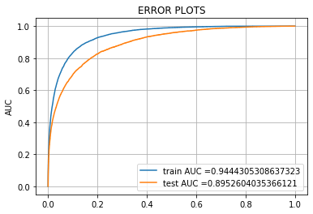

```
Time in mins:  0.8437324482166635
```

```python
start = timeit.default_timer()
# %%time
lgb_model = lgb.LGBMClassifier(boosting_type= 'gbdt', objective='binary',feature_fraction=0.05,
                              class_weight='balanced',num_leaves=8,n_estimators=2000,max_depth=5,
                              learning_rate=0.05,metric='auc',bagging_fraction=0.4, n_jobs=-1)
lgb_model.fit(X_train, y_train)

predict_y_train = batch_predict(lgb_model, X_train)
predict_y_cv = batch_predict(lgb_model, X_cv)

train_fpr, train_tpr, tr_thresholds = roc_curve(y_train, predict_y_train)
test_fpr, test_tpr, te_thresholds = roc_curve(y_cv, predict_y_cv)
plt.plot(train_fpr, train_tpr, label="train AUC ="+str(auc(train_fpr, train_tpr)))
plt.plot(test_fpr, test_tpr, label="test AUC ="+str(auc(test_fpr, test_tpr)))
plt.legend()
# plt.xlabel("K: hyperparameter")
plt.ylabel("AUC")
plt.title("ERROR PLOTS")
plt.grid()
plt.show()
stop = timeit.default_timer()
print('Time in mins: ',(stop - start)/60)
```

#### Observation

we can see that the baseline model which is trained on the raw features is giving a good auc result of 89.52%, Hence we can use it as our base model and try to improve it further with some feature engineering and get it 90% or above.

## some simple feature engineering

### simple features like sum, min, max, mean, std, skew, kurt and median as below row wise.

```python
%%time
# From the EDA we can see that we can use the sum,min,max,mean,sd,skew,kurt,med as the features for both
# train and test
# https://www.youtube.com/watch?v=LEWpRlaEJO8
idx = features = data.columns.values[2:202]
for dataFrame in [data_test, data_train]:
  dataFrame['sum'] = dataFrame[idx].sum(axis=1)
  dataFrame['min'] = dataFrame[idx].min(axis=1)
  dataFrame['max'] = dataFrame[idx].max(axis=1)
  dataFrame['mean'] = dataFrame[idx].mean(axis=1)
  dataFrame['std'] = dataFrame[idx].std(axis=1)
  dataFrame['skew'] = dataFrame[idx].skew(axis=1)
  dataFrame['kurt'] = dataFrame[idx].kurtosis(axis=1)
  dataFrame['med'] = dataFrame[idx].median(axis=1)
```

```
CPU times: user 10.9 s, sys: 739 ms, total: 11.6 s
Wall time: 11.6 s
```

```python
data_train.head(5)
```

|  | ID_code | var_0 | var_1 | var_2 | var_3 | var_4 | var_5 | var_6 | var_7 | var_8 | var_9 | var_10 | var_11 | var_12 | var_13 | var_14 | var_15 | var_16 | var_17 | var_18 | var_19 | var_20 | var_21 | var_22 | var_23 | var_24 | var_25 | var_26 | var_27 | … |
| --- | --- | --- | --- | --- | --- | --- | --- | --- | --- | --- | --- | --- | --- | --- | --- | --- | --- | --- | --- | --- | --- | --- | --- | --- | --- | --- | --- | --- | --- | --- |
| 0 | train_0 | 8.9255 | -6.7863 | 11.9081 | 5.0930 | 11.4607 | -9.2834 | 5.1187 | 18.6266 | -4.9200 | 5.7470 | 2.9252 | 3.1821 | 14.0137 | 0.5745 | 8.7989 | 14.5691 | 5.7487 | -7.2393 | 4.2840 | 30.7133 | 10.5350 | 16.2191 | 2.5791 | 2.4716 | 14.3831 | 13.4325 | -5.1488 | -0.4073 | … |
| 1 | train_1 | 11.5006 | -4.1473 | 13.8588 | 5.3890 | 12.3622 | 7.0433 | 5.6208 | 16.5338 | 3.1468 | 8.0851 | -0.4032 | 8.0585 | 14.0239 | 8.4135 | 5.4345 | 13.7003 | 13.8275 | -15.5849 | 7.8000 | 28.5708 | 3.4287 | 2.7407 | 8.5524 | 3.3716 | 6.9779 | 13.8910 | -11.7684 | -2.5586 | … |
| 2 | train_2 | 8.6093 | -2.7457 | 12.0805 | 7.8928 | 10.5825 | -9.0837 | 6.9427 | 14.6155 | -4.9193 | 5.9525 | -0.3249 | -11.2648 | 14.1929 | 7.3124 | 7.5244 | 14.6472 | 7.6782 | -1.7395 | 4.7011 | 20.4775 | 17.7559 | 18.1377 | 1.2145 | 3.5137 | 5.6777 | 13.2177 | -7.9940 | -2.9029 | … |
| 3 | train_3 | 11.0604 | -2.1518 | 8.9522 | 7.1957 | 12.5846 | -1.8361 | 5.8428 | 14.9250 | -5.8609 | 8.2450 | 2.3061 | 2.8102 | 13.8463 | 11.9704 | 6.4569 | 14.8372 | 10.7430 | -0.4299 | 15.9426 | 13.7257 | 20.3010 | 12.5579 | 6.8202 | 2.7229 | 12.1354 | 13.7367 | 0.8135 | -0.9059 | … |
| 4 | train_4 | 9.8369 | -1.4834 | 12.8746 | 6.6375 | 12.2772 | 2.4486 | 5.9405 | 19.2514 | 6.2654 | 7.6784 | -9.4458 | -12.1419 | 13.8481 | 7.8895 | 7.7894 | 15.0553 | 8.4871 | -3.0680 | 6.5263 | 11.3152 | 21.4246 | 18.9608 | 10.1102 | 2.7142 | 14.2080 | 13.5433 | 3.1736 | -3.3423 | … |

5 rows × 210 columns

```python
data_test.head(5)
```

|  | ID_code | var_0 | var_1 | var_2 | var_3 | var_4 | var_5 | var_6 | var_7 | var_8 | var_9 | var_10 | var_11 | var_12 | var_13 | var_14 | var_15 | var_16 | var_17 | var_18 | var_19 | var_20 | var_21 | var_22 | var_23 | var_24 | var_25 | var_26 | var_27 | … |
| --- | --- | --- | --- | --- | --- | --- | --- | --- | --- | --- | --- | --- | --- | --- | --- | --- | --- | --- | --- | --- | --- | --- | --- | --- | --- | --- | --- | --- | --- | --- |
| 0 | test_0 | 11.0656 | 7.7798 | 12.9536 | 9.4292 | 11.4327 | -2.3805 | 5.8493 | 18.2675 | 2.1337 | 8.8100 | -2.0248 | -4.3554 | 13.9696 | 0.3458 | 7.5408 | 14.5001 | 7.7028 | -19.0919 | 15.5806 | 16.1763 | 3.7088 | 18.8064 | 1.5899 | 3.0654 | 6.4509 | 14.1192 | -9.4902 | -2.1917 | … |
| 1 | test_1 | 8.5304 | 1.2543 | 11.3047 | 5.1858 | 9.1974 | -4.0117 | 6.0196 | 18.6316 | -4.4131 | 5.9739 | -1.3809 | -0.3310 | 14.1129 | 2.5667 | 5.4988 | 14.1853 | 7.0196 | 4.6564 | 29.1609 | 0.0910 | 12.1469 | 3.1389 | 5.2578 | 2.4228 | 16.2064 | 13.5023 | -5.2341 | -3.6648 | … |
| 2 | test_2 | 5.4827 | -10.3581 | 10.1407 | 7.0479 | 10.2628 | 9.8052 | 4.8950 | 20.2537 | 1.5233 | 8.3442 | -4.7057 | -3.0422 | 13.6751 | 3.8183 | 10.8535 | 14.2126 | 9.8837 | 2.6541 | 21.2181 | 20.8163 | 12.4666 | 12.3696 | 4.7473 | 2.7936 | 5.2189 | 13.5670 | -15.4246 | -0.1655 | … |
| 3 | test_3 | 8.5374 | -1.3222 | 12.0220 | 6.5749 | 8.8458 | 3.1744 | 4.9397 | 20.5660 | 3.3755 | 7.4578 | 0.0095 | -5.0659 | 14.0526 | 13.5010 | 8.7660 | 14.7352 | 10.0383 | -15.3508 | 2.1273 | 21.4797 | 14.5372 | 12.5527 | 2.9707 | 4.2398 | 13.7796 | 14.1408 | 1.0061 | -1.3479 | … |
| 4 | test_4 | 11.7058 | -0.1327 | 14.1295 | 7.7506 | 9.1035 | -8.5848 | 6.8595 | 10.6048 | 2.9890 | 7.1437 | 5.1025 | -3.2827 | 14.1013 | 8.9672 | 4.7276 | 14.5811 | 11.8615 | 3.1480 | 18.0126 | 13.8006 | 1.6026 | 16.3059 | 6.7954 | 3.6015 | 13.6569 | 13.8807 | 8.6228 | -2.2654 | … |

5 rows × 209 columns

### Let's take the round off feature's as well

```python
%%time
# https://www.geeksforgeeks.org/numpy-round_-python/
features_value = [col for col in data_train.columns if col not in ['ID_code','target']]
# In this we ar rounding of the value of each columns and creating a new freature of the same
for feature in features_value:
  data_train['round_2'+ feature] = np.round(data_train[feature],2)
  data_test['round_2'+ feature] = np.round(data_test[feature],2)
  data_train['round_1'+ feature] = np.round(data_train[feature],1)
  data_test['round_1'+ feature] = np.round(data_test[feature],1)
```

```
CPU times: user 4.61 s, sys: 911 ms, total: 5.52 s
Wall time: 5.52 s
```

```python
df = data_train.pop('target')
data_train['target'] = df
data_train.head(5)
```

|  | ID_code | var_0 | var_1 | var_2 | var_3 | var_4 | var_5 | var_6 | var_7 | var_8 | var_9 | var_10 | var_11 | var_12 | var_13 | var_14 | var_15 | var_16 | var_17 | var_18 | var_19 | var_20 | var_21 | var_22 | var_23 | var_24 | var_25 | var_26 | var_27 | … |
| --- | --- | --- | --- | --- | --- | --- | --- | --- | --- | --- | --- | --- | --- | --- | --- | --- | --- | --- | --- | --- | --- | --- | --- | --- | --- | --- | --- | --- | --- | --- |
| 0 | train_0 | 8.9255 | -6.7863 | 11.9081 | 5.0930 | 11.4607 | -9.2834 | 5.1187 | 18.6266 | -4.9200 | 5.7470 | 2.9252 | 3.1821 | 14.0137 | 0.5745 | 8.7989 | 14.5691 | 5.7487 | -7.2393 | 4.2840 | 30.7133 | 10.5350 | 16.2191 | 2.5791 | 2.4716 | 14.3831 | 13.4325 | -5.1488 | -0.4073 | … |
| 1 | train_1 | 11.5006 | -4.1473 | 13.8588 | 5.3890 | 12.3622 | 7.0433 | 5.6208 | 16.5338 | 3.1468 | 8.0851 | -0.4032 | 8.0585 | 14.0239 | 8.4135 | 5.4345 | 13.7003 | 13.8275 | -15.5849 | 7.8000 | 28.5708 | 3.4287 | 2.7407 | 8.5524 | 3.3716 | 6.9779 | 13.8910 | -11.7684 | -2.5586 | … |
| 2 | train_2 | 8.6093 | -2.7457 | 12.0805 | 7.8928 | 10.5825 | -9.0837 | 6.9427 | 14.6155 | -4.9193 | 5.9525 | -0.3249 | -11.2648 | 14.1929 | 7.3124 | 7.5244 | 14.6472 | 7.6782 | -1.7395 | 4.7011 | 20.4775 | 17.7559 | 18.1377 | 1.2145 | 3.5137 | 5.6777 | 13.2177 | -7.9940 | -2.9029 | … |
| 3 | train_3 | 11.0604 | -2.1518 | 8.9522 | 7.1957 | 12.5846 | -1.8361 | 5.8428 | 14.9250 | -5.8609 | 8.2450 | 2.3061 | 2.8102 | 13.8463 | 11.9704 | 6.4569 | 14.8372 | 10.7430 | -0.4299 | 15.9426 | 13.7257 | 20.3010 | 12.5579 | 6.8202 | 2.7229 | 12.1354 | 13.7367 | 0.8135 | -0.9059 | … |
| 4 | train_4 | 9.8369 | -1.4834 | 12.8746 | 6.6375 | 12.2772 | 2.4486 | 5.9405 | 19.2514 | 6.2654 | 7.6784 | -9.4458 | -12.1419 | 13.8481 | 7.8895 | 7.7894 | 15.0553 | 8.4871 | -3.0680 | 6.5263 | 11.3152 | 21.4246 | 18.9608 | 10.1102 | 2.7142 | 14.2080 | 13.5433 | 3.1736 | -3.3423 | … |

5 rows × 626 columns

```python
data_test.head(5)
```

|  | ID_code | var_0 | var_1 | var_2 | var_3 | var_4 | var_5 | var_6 | var_7 | var_8 | var_9 | var_10 | var_11 | var_12 | var_13 | var_14 | var_15 | var_16 | var_17 | var_18 | var_19 | var_20 | var_21 | var_22 | var_23 | var_24 | var_25 | var_26 | var_27 | … |
| --- | --- | --- | --- | --- | --- | --- | --- | --- | --- | --- | --- | --- | --- | --- | --- | --- | --- | --- | --- | --- | --- | --- | --- | --- | --- | --- | --- | --- | --- | --- |
| 0 | test_0 | 11.0656 | 7.7798 | 12.9536 | 9.4292 | 11.4327 | -2.3805 | 5.8493 | 18.2675 | 2.1337 | 8.8100 | -2.0248 | -4.3554 | 13.9696 | 0.3458 | 7.5408 | 14.5001 | 7.7028 | -19.0919 | 15.5806 | 16.1763 | 3.7088 | 18.8064 | 1.5899 | 3.0654 | 6.4509 | 14.1192 | -9.4902 | -2.1917 | … |
| 1 | test_1 | 8.5304 | 1.2543 | 11.3047 | 5.1858 | 9.1974 | -4.0117 | 6.0196 | 18.6316 | -4.4131 | 5.9739 | -1.3809 | -0.3310 | 14.1129 | 2.5667 | 5.4988 | 14.1853 | 7.0196 | 4.6564 | 29.1609 | 0.0910 | 12.1469 | 3.1389 | 5.2578 | 2.4228 | 16.2064 | 13.5023 | -5.2341 | -3.6648 | … |
| 2 | test_2 | 5.4827 | -10.3581 | 10.1407 | 7.0479 | 10.2628 | 9.8052 | 4.8950 | 20.2537 | 1.5233 | 8.3442 | -4.7057 | -3.0422 | 13.6751 | 3.8183 | 10.8535 | 14.2126 | 9.8837 | 2.6541 | 21.2181 | 20.8163 | 12.4666 | 12.3696 | 4.7473 | 2.7936 | 5.2189 | 13.5670 | -15.4246 | -0.1655 | … |
| 3 | test_3 | 8.5374 | -1.3222 | 12.0220 | 6.5749 | 8.8458 | 3.1744 | 4.9397 | 20.5660 | 3.3755 | 7.4578 | 0.0095 | -5.0659 | 14.0526 | 13.5010 | 8.7660 | 14.7352 | 10.0383 | -15.3508 | 2.1273 | 21.4797 | 14.5372 | 12.5527 | 2.9707 | 4.2398 | 13.7796 | 14.1408 | 1.0061 | -1.3479 | … |
| 4 | test_4 | 11.7058 | -0.1327 | 14.1295 | 7.7506 | 9.1035 | -8.5848 | 6.8595 | 10.6048 | 2.9890 | 7.1437 | 5.1025 | -3.2827 | 14.1013 | 8.9672 | 4.7276 | 14.5811 | 11.8615 | 3.1480 | 18.0126 | 13.8006 | 1.6026 | 16.3059 | 6.7954 | 3.6015 | 13.6569 | 13.8807 | 8.6228 | -2.2654 | … |

5 rows × 625 columns

```python
print("total number of features after feature engineering",len(data_train.columns))
```

```
total number of features after feature engineering 626
```

```python
print("total number of features after feature engineering",len(data_test.columns))
```

```
total number of features after feature engineering 625
```

```python
# data_train.to_csv('data_train_final.csv', index = False)
data_train_final_ = pd.read_csv('data_train_final.csv')
```

```python
# data_test.to_csv('data_test_final.csv', index = False)
data_test_final_ = pd.read_csv('data_test_final.csv')
```

```python
df_test = data_test_final_.pop('ID_code')
```

```python
data_test_final_
```

|  | var_0 | var_1 | var_2 | var_3 | var_4 | var_5 | var_6 | var_7 | var_8 | var_9 | var_10 | var_11 | var_12 | var_13 | var_14 | var_15 | var_16 | var_17 | var_18 | var_19 | var_20 | var_21 | var_22 | var_23 | var_24 | var_25 | var_26 | var_27 | var_28 | … |
| --- | --- | --- | --- | --- | --- | --- | --- | --- | --- | --- | --- | --- | --- | --- | --- | --- | --- | --- | --- | --- | --- | --- | --- | --- | --- | --- | --- | --- | --- | --- |
| 0 | 11.0656 | 7.7798 | 12.9536 | 9.4292 | 11.4327 | -2.3805 | 5.8493 | 18.2675 | 2.1337 | 8.8100 | -2.0248 | -4.3554 | 13.9696 | 0.3458 | 7.5408 | 14.5001 | 7.7028 | -19.0919 | 15.5806 | 16.1763 | 3.7088 | 18.8064 | 1.5899 | 3.0654 | 6.4509 | 14.1192 | -9.4902 | -2.1917 | 5.7107 | … |
| 1 | 8.5304 | 1.2543 | 11.3047 | 5.1858 | 9.1974 | -4.0117 | 6.0196 | 18.6316 | -4.4131 | 5.9739 | -1.3809 | -0.3310 | 14.1129 | 2.5667 | 5.4988 | 14.1853 | 7.0196 | 4.6564 | 29.1609 | 0.0910 | 12.1469 | 3.1389 | 5.2578 | 2.4228 | 16.2064 | 13.5023 | -5.2341 | -3.6648 | 5.7080 | … |
| 2 | 5.4827 | -10.3581 | 10.1407 | 7.0479 | 10.2628 | 9.8052 | 4.8950 | 20.2537 | 1.5233 | 8.3442 | -4.7057 | -3.0422 | 13.6751 | 3.8183 | 10.8535 | 14.2126 | 9.8837 | 2.6541 | 21.2181 | 20.8163 | 12.4666 | 12.3696 | 4.7473 | 2.7936 | 5.2189 | 13.5670 | -15.4246 | -0.1655 | 7.2633 | … |
| 3 | 8.5374 | -1.3222 | 12.0220 | 6.5749 | 8.8458 | 3.1744 | 4.9397 | 20.5660 | 3.3755 | 7.4578 | 0.0095 | -5.0659 | 14.0526 | 13.5010 | 8.7660 | 14.7352 | 10.0383 | -15.3508 | 2.1273 | 21.4797 | 14.5372 | 12.5527 | 2.9707 | 4.2398 | 13.7796 | 14.1408 | 1.0061 | -1.3479 | 5.2570 | … |
| 4 | 11.7058 | -0.1327 | 14.1295 | 7.7506 | 9.1035 | -8.5848 | 6.8595 | 10.6048 | 2.9890 | 7.1437 | 5.1025 | -3.2827 | 14.1013 | 8.9672 | 4.7276 | 14.5811 | 11.8615 | 3.1480 | 18.0126 | 13.8006 | 1.6026 | 16.3059 | 6.7954 | 3.6015 | 13.6569 | 13.8807 | 8.6228 | -2.2654 | 5.2255 | … |
| ... | ... | ... | ... | ... | ... | ... | ... | ... | ... | ... | ... | ... | ... | ... | ... | ... | ... | ... | ... | ... | ... | ... | ... | ... | ... | ... | ... | ... | ... | … |
| 199995 | 13.1678 | 1.0136 | 10.4333 | 6.7997 | 8.5974 | -4.1641 | 4.8579 | 14.7625 | -2.7239 | 6.9937 | 2.6802 | 6.1565 | 14.3201 | 17.4594 | 5.3712 | 14.8984 | 5.8064 | -10.0334 | 16.4220 | 30.7786 | 22.7696 | 9.8526 | 4.0207 | 3.8469 | 13.1617 | 13.2522 | -12.4547 | -1.9127 | 5.3696 | … |
| 199996 | 9.7171 | -9.1462 | 7.3443 | 9.1421 | 12.8936 | 3.0191 | 5.6888 | 18.8862 | 5.0915 | 6.3545 | 3.2618 | -2.0445 | 13.8246 | 6.6547 | 5.0309 | 14.1999 | 8.5685 | 3.8190 | 11.4428 | 19.6761 | 22.4473 | 16.6921 | 5.5064 | 3.6160 | 10.4145 | 13.5557 | 0.0592 | -1.8571 | 6.3351 | … |
| 199997 | 11.6360 | 2.2769 | 11.2074 | 7.7649 | 12.6796 | 11.3224 | 5.3883 | 18.3794 | 1.6603 | 5.7341 | 9.8596 | -0.3412 | 14.0675 | 13.9975 | 6.2574 | 15.1456 | 8.1250 | -7.3642 | 15.4767 | 15.9472 | 16.6580 | 16.0286 | 0.6066 | 3.5773 | 4.4758 | 13.8995 | -9.1787 | -2.3696 | 4.6504 | … |
| 199998 | 13.5745 | -0.5134 | 13.6584 | 7.4855 | 11.2241 | -11.3037 | 4.1959 | 16.8280 | 5.3208 | 8.9032 | 5.5000 | -13.1346 | 14.3051 | 4.2644 | 11.1258 | 14.7810 | 10.7184 | -11.1223 | 14.3151 | 11.8348 | 12.2356 | 20.9599 | 1.1101 | 3.0801 | 6.2626 | 14.0242 | 3.6157 | -1.3483 | 6.5041 | … |
| 199999 | 10.4664 | 1.8070 | 10.2277 | 6.0654 | 10.0258 | 1.0789 | 4.8879 | 14.4892 | -0.5902 | 7.8362 | 8.4796 | -5.8960 | 13.8333 | 2.4590 | 7.8881 | 14.8566 | 10.4665 | -11.8235 | 25.2430 | 20.9039 | 19.0743 | 15.5896 | -2.1275 | 2.9672 | 2.0289 | 13.9641 | -2.7192 | 0.9102 | 4.1522 | … |

200000 rows × 624 columns

### Let's train lightgbm model on this dataset

```python
y = data_train_final_['target']
x = data_train_final_.drop(['ID_code','target'],axis=1)
```

```python
parameter = {
    'bagging_freq': 5,
    'bagging_fraction': 0.4,
    'boost_from_average':'false',
    'boost': 'gbdt',
    'feature_fraction': 0.05,
    'learning_rate': 0.01,
    'max_depth': -1,
    'metric':'auc',
    'min_data_in_leaf': 80,
    'min_sum_hessian_in_leaf': 10.0,
    'num_leaves': 13,
    'num_threads': 8,
    'tree_learner': 'serial',
    'objective': 'binary',
    'verbosity': 1
}
```

```python
# https://www.kaggle.com/adrianlievano/light-gbm-with-stratified-kfold
# Getting all the features name except the ID_code , target
features = [col for col in data_train_final_.columns if col not in ['ID_code', 'target']]
# Inititalizing the K-Fold object
K_folds = StratifiedKFold(n_splits=10, shuffle=False, random_state=44000)
# this creates the empty numpy array of length of x in which we store the prediction of every validation data
val_pred = np.zeros(len(x))
# In this we keep the predicted output of the test data
predictions_test = np.zeros(len(data_test_final_))
#In this loop we are doing the training and prediction for each folds and we are getting the train and valid data
# using the trn_idx and val_idx
for n_fold, (trn_idx, val_idx) in enumerate(K_folds.split(x.values, y.values)):
    print("Fold {}".format(n_fold))
    # Getting the train and validation data from the x data
    train_data = lgb.Dataset(x.iloc[trn_idx][features], label=y.iloc[trn_idx])
    valid_data = lgb.Dataset(x.iloc[val_idx][features], label=y.iloc[val_idx])
    # Here we are training lightgbm model on train and valid dataset
    num_round = 1000000
    classifier = lgb.train(parameter, train_data, num_round,
                           valid_sets = [train_data, valid_data],
                           verbose_eval=1000, early_stopping_rounds = 3000)
    # Here we are doing the prediction on the valid data
    val_pred[val_idx] = classifier.predict(x.iloc[val_idx][features], num_iteration=classifier.best_iteration)
    # And here we are doing the prediction on the test data
    predictions_test += classifier.predict(data_test_final_[features],
                                           num_iteration=classifier.best_iteration) / K_folds.n_splits
print("CV score: {:<8.5f}".format(roc_auc_score(y, val_pred)))
```

```
Fold 0
Training until validation scores don't improve for 3000 rounds.
[1000]	training's auc: 0.884606	valid_1's auc: 0.864238
[2000]	training's auc: 0.909543	valid_1's auc: 0.884301
[3000]	training's auc: 0.921172	valid_1's auc: 0.892468
[4000]	training's auc: 0.928569	valid_1's auc: 0.896445
[5000]	training's auc: 0.934233	valid_1's auc: 0.898244
[6000]	training's auc: 0.93909	valid_1's auc: 0.89918
[7000]	training's auc: 0.943654	valid_1's auc: 0.89976
[8000]	training's auc: 0.947872	valid_1's auc: 0.89997
[9000]	training's auc: 0.951984	valid_1's auc: 0.900189
[10000]	training's auc: 0.955868	valid_1's auc: 0.900104
[11000]	training's auc: 0.959515	valid_1's auc: 0.900119
Early stopping, best iteration is:
[8864]	training's auc: 0.951432	valid_1's auc: 0.900263
Fold 1
Training until validation scores don't improve for 3000 rounds.
[1000]	training's auc: 0.885043	valid_1's auc: 0.865176
[2000]	training's auc: 0.909497	valid_1's auc: 0.884609
[3000]	training's auc: 0.921101	valid_1's auc: 0.892007
[4000]	training's auc: 0.928448	valid_1's auc: 0.895779
[5000]	training's auc: 0.934179	valid_1's auc: 0.897228
[6000]	training's auc: 0.939098	valid_1's auc: 0.898258
[7000]	training's auc: 0.943683	valid_1's auc: 0.898647
[8000]	training's auc: 0.947879	valid_1's auc: 0.898747
[9000]	training's auc: 0.951974	valid_1's auc: 0.89876
[10000]	training's auc: 0.955782	valid_1's auc: 0.898835
[11000]	training's auc: 0.959523	valid_1's auc: 0.898605
Early stopping, best iteration is:
[8706]	training's auc: 0.950803	valid_1's auc: 0.898912
Fold 2
Training until validation scores don't improve for 3000 rounds.
[1000]	training's auc: 0.885983	valid_1's auc: 0.861552
[2000]	training's auc: 0.910108	valid_1's auc: 0.880106
[3000]	training's auc: 0.921748	valid_1's auc: 0.8875
[4000]	training's auc: 0.929068	valid_1's auc: 0.891016
[5000]	training's auc: 0.934709	valid_1's auc: 0.892928
[6000]	training's auc: 0.939557	valid_1's auc: 0.89385
[7000]	training's auc: 0.944015	valid_1's auc: 0.894434
[8000]	training's auc: 0.948275	valid_1's auc: 0.89449
```

[output cut: 97 more lines]

```
[2000]	training's auc: 0.909302	valid_1's auc: 0.887962
[3000]	training's auc: 0.921136	valid_1's auc: 0.89503
[4000]	training's auc: 0.928514	valid_1's auc: 0.898296
[5000]	training's auc: 0.934177	valid_1's auc: 0.899851
[6000]	training's auc: 0.939089	valid_1's auc: 0.90058
[7000]	training's auc: 0.943661	valid_1's auc: 0.901047
[8000]	training's auc: 0.947907	valid_1's auc: 0.901073
[9000]	training's auc: 0.951996	valid_1's auc: 0.901121
[10000]	training's auc: 0.95587	valid_1's auc: 0.901159
[11000]	training's auc: 0.959491	valid_1's auc: 0.901077
[12000]	training's auc: 0.962948	valid_1's auc: 0.900954
[13000]	training's auc: 0.966231	valid_1's auc: 0.900753
Early stopping, best iteration is:
[10394]	training's auc: 0.957302	valid_1's auc: 0.901253
CV score: 0.90000
```

### Creating the submission dataframe

```python
sub_df = pd.DataFrame({"ID_code":data_test["ID_code"].values})
sub_df["target"] = predictions
sub_df.to_csv("submission.csv", index=False)
```

```python
sub_data = pd.read_csv("submission.csv")
```

```python
sub_data
```

|  | ID_code | target |
| --- | --- | --- |
| 0 | test_0 | 0.088934 |
| 1 | test_1 | 0.227910 |
| 2 | test_2 | 0.170440 |
| 3 | test_3 | 0.204776 |
| 4 | test_4 | 0.042111 |
| ... | ... | ... |
| 199995 | test_199995 | 0.036870 |
| 199996 | test_199996 | 0.007906 |
| 199997 | test_199997 | 0.004250 |
| 199998 | test_199998 | 0.091177 |
| 199999 | test_199999 | 0.063739 |

200000 rows × 2 columns